# RNA-seq Analysis in R

Annotation and Visualisation of RNA-seq results - Solutions

Stephane Ballereau, Mark Dunning, Oscar Rueda, Ashley Sawle

Last modified: 31 Aug 2018

```r
# load data
load("../Robjects/DE.RData")
## set up connection to ensembl database
ensembl=useMart("ENSEMBL_MART_ENSEMBL")
# list the available datasets (species)
listDatasets(ensembl) %>%
    filter(str_detect(description, "Mouse"))
# specify a data set to use
ensembl = useDataset("mmusculus_gene_ensembl", mart=ensembl)
# Set the filter type and values
filterType <- "ensembl_gene_id"
# annotated
load("../Robjects/Ensembl_annotations.RData")
annotLvV <- as.data.frame(resLvV) %>%
    rownames_to_column("GeneID") %>%
    left_join(ensemblAnnot, "GeneID") %>%
    rename(logFC=log2FoldChange, FDR=padj)
# txdb object
txMm <- makeTxDbFromBiomart(dataset="mmusculus_gene_ensembl")
```

### Challenge 1

> That was just 1000 genes. We need annotations for the entire results table. Also, there may be some other interesting columns in BioMart that we wish to retrieve.
> 1. Search the attributes and add the following to our list of attributes:
>    1. The gene description
>    2. The genomic position - chromosome, start, end, and strand (4 columns)
>    3. The gene biotype
> 2. Query BioMart using all of the genes in our results table (`resLvV`)
> 3. How many Ensembl genes have multipe Entrez IDs associated with them?
> 4. How many Ensembl genes in `resLvV` don’t have any annotation? Why is this?

```r
filterValues <- rownames(resLvV)

# check the available "attributes" - things you can retreive
listAttributes(ensembl) %>%
    head(20)
attributeNames <- c('ensembl_gene_id',
                    'entrezgene',
                    'external_gene_name',
                    'description',
                    'gene_biotype',
                    'chromosome_name',
                    'start_position',
                    'end_position',
                    'strand')

# run the query
annot <- getBM(attributes=attributeNames,
               filters = filterType,
               values = filterValues,
               mart = ensembl)

# dulicate ids
sum(duplicated(annot$ensembl_gene_id))

# missing gens
missingGenes <- !rownames(resLvV)%in%annot$ensembl_gene_id
rownames(resLvV)[missingGenes]
```

[output not shown]

### Challenge 2

> Use the log2 fold change (`logFC`) on the x-axis, and use `-log10(FDR)` on the y-axis. (This >`-log10` transformation is commonly used for p-values as it means that more significant genes have a >higher scale)
> 1. Create a column of -log10(FDR) values
> 2. Create a plot with points coloured by if FDR < 0.05

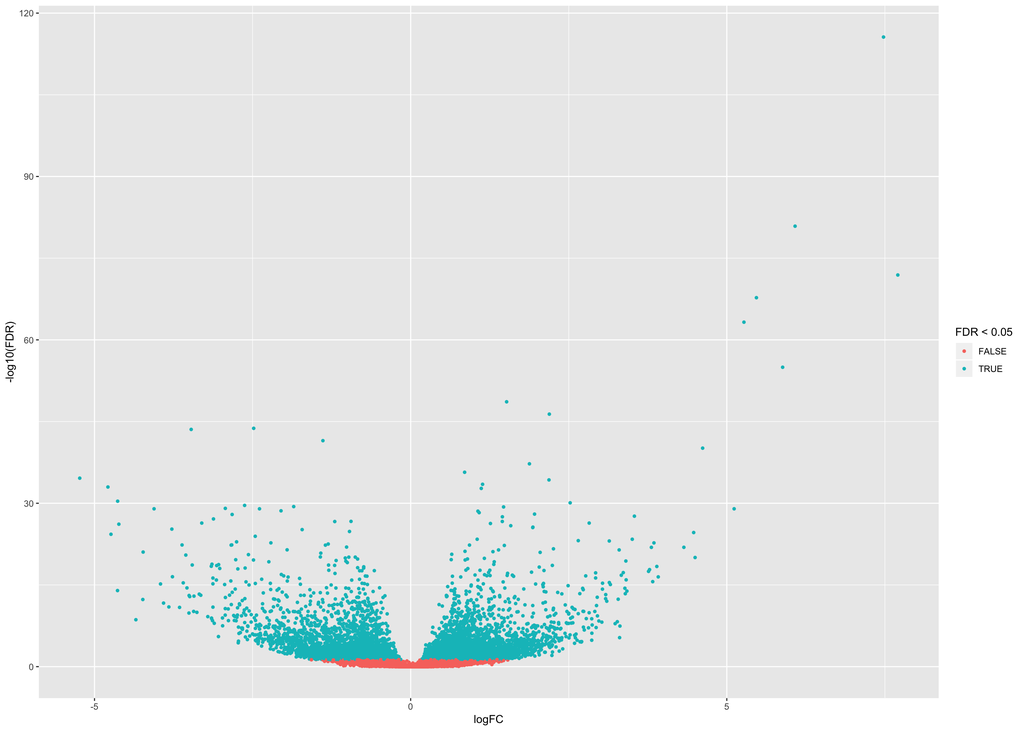

```r
# first remove the filtered genes (FDR=NA) and create a -log10(FDR) column
filtTab <- shrinkLvV %>%
    filter(!is.na(FDR)) %>%
    mutate(`-log10(FDR)` = -log10(FDR))
ggplot(filtTab, aes(x = logFC, y=`-log10(FDR)`)) +
    geom_point(aes(colour=FDR < 0.05), size=1)
```

### Challenge 3 {.challenge} - In Supplementary Materials

> Use the txMm to retrieve the exon coordinates for the genes: + `ENSMUSG00000021604` + `ENSMUSG00000022146` + `ENSMUSG00000040118`